# BSAN2204

Tutorial 2 - R and R Studio

## Using `R` in R Studio

In the last session we met each other and had our first introductions to `R` and R Studio. Today we will continue to get to know each other a bit better, and begin to expand our knowledge and skills working with `R`.

The most recent lecture covered defining what `R` is, and how most people tend to work with `R` using R Studio. Some of this content will be tested in the R Skills quiz, so make sure you study it!

If you have not yet installed `R` and R Studio, now is the time to do it. The lecture gives some guidance on how to install both pieces of software.

## Getting familiar with R Studio

Before we begin, lets talk in groups briefly. Turn to someone nearby and ask the following:

Have you installed `R` and R Studio yet?

Have you learnt any programming languages before?

Do you have any fears about coding?

AI can generate complex code in seconds. How essential do you think it is to learn to code now?

## R Studio makes `R` easier

Learning `R` (or any new language, computer or otherwise) is hard at first. R Studio is a more user-friendly interface than `R` alone, which makes it a lot easier to both learn and use in business analytics workflows.

The biggest challenge in `R` usually arises from the fact that a high degree of precision is required from the user. Things do not “just work” like they might in other software.

Troubleshooting errors in `R` requires the user to understand the basic logic of `R` syntax, data structures and workflows.

## Copilot (AI) also makes `R` easier

To AI or not to AI…? that is a good question.

R Studio now comes bundled with Copilot generative AI which can provide auto completion suggestions for both code and narrative text.

You can enable Copilot in R Studio under Tools > Global Options.

Using generative AI to write/edit code code delivers some serious productivity advantages, but our suggestion is to first convince yourself that you can read and understand the logic of `R` syntax before using auto complete suggestions.

## Troubleshooting `R`

There are many resources for troubleshooting errors or for looking to solutions to coding problems. [StackOverflow](https://stackoverflow.com/questions/tagged/r) was where people used to find solutions to common problems but since AI has become widespread it has been in steep decline.

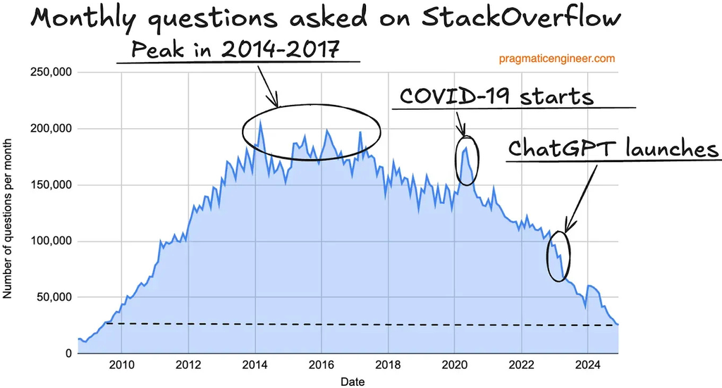

## Using AI for `R` help

A good prompt to generate `R` code should include specific instructions on what type data structures you want to work with. Thus, it is important to have a basic grasp of `R` syntax and data structures so that your prompts can be specific, for example:

*“label the levels of a factor variable in R called key which has 11 levels (ordered according to the chromatic scale)”* is better than *“help fix my code so it looks right”*

When a block of code continually throws an error message despite all your best efforts to resolve it, pasting it into a generate AI tool will likely lead to a quick solution. You should use generative AI tools cautiously. They will often suggest to use overly complex methods, or do things which go beyond your immediate needs.

## `R` documentation

Whilst the utility of `R` forums may be in decline, the utility of the official `R` documentation pages will always remain useful.

To check how any particular function works, view the Help tab in the lower right window.

You can also type `?` followed by the function name in the console. For example, documentation for the `factor()` can be found using `?factor`

## `R` Textbooks

These are becoming less and less relevant, although they do remain to be a stable and reliable source of structured information which some students find useful to work through systematically.

The recommended text for BSAN2204 is:

Kabacoff (2022), *R in Action: Data Analysis and Graphics with R and Tidyverse. 3rd Edition*

Many of the example code which will shown in upcoming lectures have been adopted from this text (although they are slowly being phased out as the course iteratively re-written year to year).

## Changing the R Studio theme

To change the R Studio theme:

- Select Tools (top menu)
- Select Global Options
- Select Appearance
- Select an Editor Theme

[figure not shown]

## R Studio themes

Customising the appearance of R Studio to suit our own preferences is both fun and can enhance your productivity. Switching between light and dark modes can be particularly beneficial if you work better in low light settings.

[figure not shown]

[figure not shown]

## Understanding `R` syntax

The syntax of any language refers to the set of rules that define how code must be written so that a programming language can understand and execute it correctly.

In `R`, syntax is the grammar, and data structures are the vocabulary. To write meaningful code, you need to study both.

We will practice the lecture content from here on, focusing on `R` syntax for assignment of values within various data structures.

## Data structures in `R`

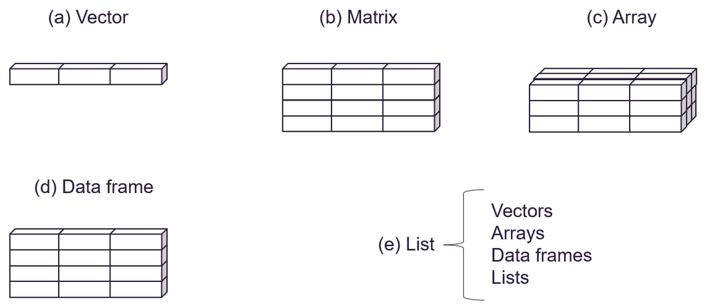

## Creating data

Recall the following from the last session:

```r
age <- c(1, 3, 5, 2, 11, 9, 3, 9, 12, 3)
```

How does this line of code work?

First it starts by defining what the object is going to be called (here we are choosing “age”). This can be *almost* anything. We typically chose a word or abbreviation that describes what the object will hold.

Try creating your own object. Did it work? What did you try?

## Object name rules

Object names can include letters, numbers, underscores, and periods/dots, but they cannot start with a number and cannot include spaces. Object names are case sensitive (`age` and `Age` are different).

```r
1age <- c(1, 3, 5, 2, 11, 9, 3, 9, 12, 3)
```

```
Error in parse(text = input): <text>:1:2: unexpected symbol
1: 1age
     ^
```

```r
list of ages <- c(1, 3, 5, 2, 11, 9, 3, 9, 12, 3)
```

```
Error in parse(text = input): <text>:1:6: unexpected symbol
1: list of
         ^
```

These all result in different objects:

```r
age <- c(1, 3, 5, 2, 11, 9, 3, 9, 12, 3)
Age <- c(7, 14, 2, 28, 19, 5, 23, 11, 26, 8)
AGE <- c(4, 17, 25, 6, 13, 22, 1, 27, 10, 18)
age_1 <- c(4, 17, 25, 6, 13, 22, 1, 27, 10, 18)
```

## Vectors

Vectors can only contain one type of data (they cannot mix and match types). Vectors are one dimensional (1d), which means they do not have any rows or columns. You can think of them like a single row (or column). For example, here is a character vector of the names of numeric variables from the assignment data:

```r
varlist_numeric <- c("artist_familiarity",
  "artist_hotttnesss",
  "duration",
  "end_of_fade_in",
  "loudness",
  "start_of_fade_out",
  "tempo",
  "year")
```

The above character may come in hand in your reports later. It can be used to produce descriptive statistics for all of these variables by supplying the object (called `varlist_numeric`) to a `describe()` function, rather than writing out the whole list.

## Matrices

A matrix is two dimensional (2d), which has rows and columns. A common technique in `R` when matrix is to first define an empty matrix, before filling it with values. The example below sets up matrix `nrow = 10` and `ncol = 4`, i.e., a 10 x 4 matrix.

```r
age_matrix <- matrix(nrow = 10, ncol = 4)
```

If we view this matrix we will see it contains all `NA` values, which is how `R` denotes missing data.

```r
print(age_matrix)
```

```
      [,1] [,2] [,3] [,4]
 [1,]   NA   NA   NA   NA
 [2,]   NA   NA   NA   NA
 [3,]   NA   NA   NA   NA
 [4,]   NA   NA   NA   NA
 [5,]   NA   NA   NA   NA
 [6,]   NA   NA   NA   NA
 [7,]   NA   NA   NA   NA
 [8,]   NA   NA   NA   NA
 [9,]   NA   NA   NA   NA
[10,]   NA   NA   NA   NA
```

## Fill a matrix with vectors

We can fill the empty matrix using the four different age vectors we setup earlier, and using square brackets `[]` to control which columns of the matrix we put this data in.

```r
age_matrix[, 1] <- age
age_matrix[, 2] <- Age
age_matrix[, 3] <- AGE
age_matrix[, 4] <- age_1
```

See how the above assigns (`<-`):

`age` to column 1

`Age` to column 2

`AGE` to column 3, and

`age_1` to column 4

## Naming matrix columns

We can optionally name the columns of matrix. This then allows us to reference the column by name instead of by column number.

```r
colnames(age_matrix) <- c("age", "Age", "AGE", "age_1")
print(age_matrix)
```

```
      age Age AGE age_1
 [1,]   1   7   4     4
 [2,]   3  14  17    17
 [3,]   5   2  25    25
 [4,]   2  28   6     6
 [5,]  11  19  13    13
 [6,]   9   5  22    22
 [7,]   3  23   1     1
 [8,]   9  11  27    27
 [9,]  12  26  10    10
[10,]   3   8  18    18
```

## Extracting values using `[]`

Recall that square brackets contain `[row, column]` references which allow us to refer to positions within a matrix by their row, column position (coordinates). When using the `[row, column]` indexing syntax for a matrix in `R`, leaving one of the coordinates blank tells `R` to return all values along that dimension.

What is at the intersection of row 3 and column 4?

```r
age_matrix[3,4]
```

```
age_1
   25
```

What is in row 3?

```r
age_matrix[3,]
```

```
  age   Age   AGE age_1
    5     2    25    25
```

What is in column 4?

```r
age_matrix[,4]
```

```
 [1]  4 17 25  6 13 22  1 27 10 18
```

## Extracting values using names

If the columns of the matrix are named, we use the name inside square brackets `[]` inside of having to know or remember the column number.

```r
print(age_matrix[,"age_1"])
```

```
 [1]  4 17 25  6 13 22  1 27 10 18
```

## Arrays and Dataframes

An array extends a matrix to have multiple dimensions each with the same number of rows and columns. A three dimensional (3d) array is a cube of data a whereas 4d (or above) array stacks multiple cubes in a row. Each cube is a 3d slice, and the dimension number indexes which cube you are in. Like vectors and matrices, arrays can only store one type of data.

A dataframe is more general and flexible than an array in `R`. They designed to handle heterogeneous, labelled, and tabular data, whereas arrays are strictly homogeneous and multi-dimensional.

We will explore the data frame stored in the `MSD.Rdata` file throughout tutorials in BSAN2204.

## Lists

Lists can encompass any/all of the mentioned data types. Lists are commonly produced as the outputs of certain `R` functions. We can have a list of vectors, a list of dataframes, etc.

```r
load("MSD.Rdata")
model <- lm(song_hotttnesss ~
              duration +
              end_of_fade_in +
              loudness +
              start_of_fade_out +
              tempo +
              year,
            data = MSD)
summary(model)
```

[output not shown]

If we check the type of object produced by `summary(model)` we will see that is is a list.

```r
typeof(summary(model))
```

```
[1] "list"
```

## Using `print()`

We have seen this function a number of times here to output values as raw console output. This function should only be used to inspect the data for your own purposes but it should **not** be included in professional reports where it will be preferable to format the outputs to look nicer.

This slidedeck does *not* practice what it preaches!

Here we are demonstrating the use of more fundamental components of `R` and only saving our work in a `.r` file. In the next session, we will transition to using R Markdown and will save our work in a `.Rmd` file which can be used as a template file.

## What comes next?

In the next session we start constructing a template `.Rmd` R Markdown file which can be used to generate business analytics reports, including its essential section headings and some basic code within its `R` chunk sections.

Some of the basic `R` operations we have learnt in this session will be put to use as we start to build the template `.Rmd` R Markdown file.

Thank you!